# Definisi :

## 1. Selection Sort

Selection Sort adalah algoritma pengurutan sederhana yang membagi daftar menjadi dua bagian: bagian yang sudah diurutkan dan bagian yang belum diurutkan. Algoritma ini bekerja dengan cara mencari elemen terkecil secara berulang dari bagian yang belum diurutkan, lalu memindahkan dan menukarnya ke posisi paling depan dari bagian tersebut.

### Cara Kerja:

- Mengasumsikan elemen pertama pada bagian yang belum diurutkan sebagai nilai terkecil sementara (minimum).
- Membandingkan nilai minimum sementara tersebut dengan elemen-elemen berikutnya dalam sisa daftar.
- Jika ditemukan elemen yang nilainya lebih kecil ($Ist[j] < minimum$), maka elemen tersebut diperbarui menjadi nilai minimum yang baru.
- Setelah selesai memeriksa hingga akhir daftar, tukar nilai minimum yang ditemukan dengan elemen pertama dari bagian yang belum diurutkan.
- Geser batas daftar yang belum diurutkan satu posisi ke kanan, lalu ulangi proses ini hingga seluruh elemen selesai diurutkan.

Berikut ilustrasi algoritma selection sort ini. Misalkan terdapat suatu data, yaitu [7, 2.5, 5, 10, 1]. Maka proses pengurutan secara ascending (dari nilai kecil sampai dengna nilai besar) dengan menggunakan algoritma Selection Sort adalah sebagai berikut :

Iterasi Pertama. Pada iterasi pertama ini, data yang memiliki nilai paling kecil, akan menempati posisi dengan indeks paling awal. Untuk mencari data dengan nilai paling kecil ini, dilakukan perbandingan sebagai berikut:

1. antara indeks ke-0 dengan ke-1, sehingga nilai terkecil saat ini adalah 2.5
2. antara indeks ke-1 dengan ke-2, nilai terkecil tetaplah 2.5
3. antara indeks ke-2 dengan ke-3, nilai terkecil tetaplah 2.5
4. antara indeks ke-3 dengan ke-4, didapatkan nilai terkecil adalah 1. Pada saat pencarian nilai terkecil ini tidak dilakukan proses pertukaran posisi (berbeda dengan a;goritma bubble sort). Setelah didapatkan nilai terkecil, maka nilai 1 ini akan ditukar dengan data pada posisi dengan indeks ke-0, sehingga setelah iterasi pertama berakhir, data 1, akan menempati indeks ke-0. Ilustrasi iterasi pertama ini dapat dilihat pada Gambar 1.

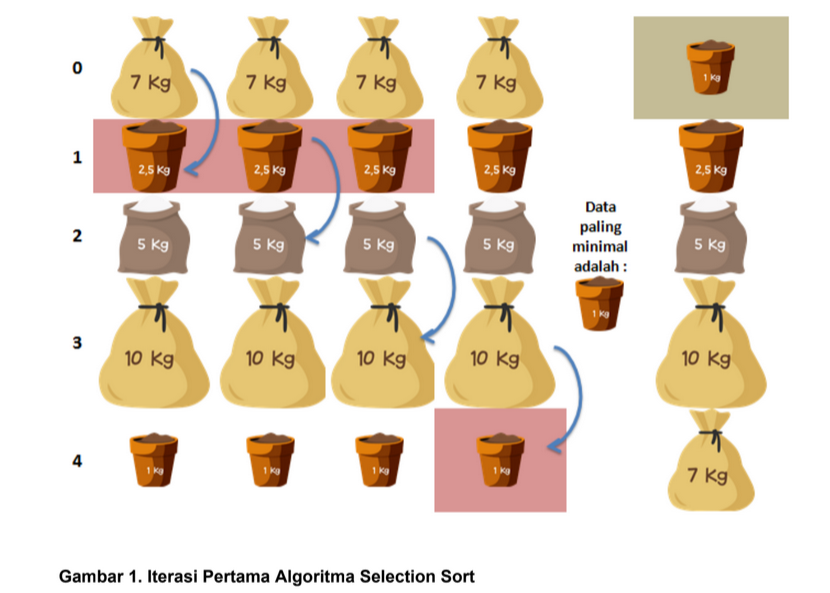

Iterasi Kedua. Pada iterasi kedua ini, data yang memiliki nilai paling kecil kedua, akan menempati posisi dengan indeks setelah data paling kecil, yaitu indeks ke-1. Untuk mencari data dengan nilai paling kecil kedua ini, dilakukan perbandingan, hanya saja data pada indeks ke-0 tidak perlu dibandingkan lagi, karena data pada indeks ke-0 sudah berisi data yang tepat. Perbandingan yang dilakukan untuk mencari nilai minimal kedua adalah sebagai berikut:

1. antara indeks ke-1 dengan ke-2, nilai terkecil tetaplah 2.5
2. antara indeks ke-2 dengan ke-3, nilai terkecil tetaplah 2.5
3. antara indeks ke-3 dengan ke-4, didapatkan nilai terkecil adalah 2.5 Setelah didapatkan nilai minimal, yaitu 2.5, maka nilai ini akan ditukar dengan data pada posisi dengan indeks ke-1, sehingga setelah iterasi kedua berakhir, data 2.5, akan menempati indeks ke-1. Ilustrasi iterasi kedua ini dapat dilihat pada Gambar 2.

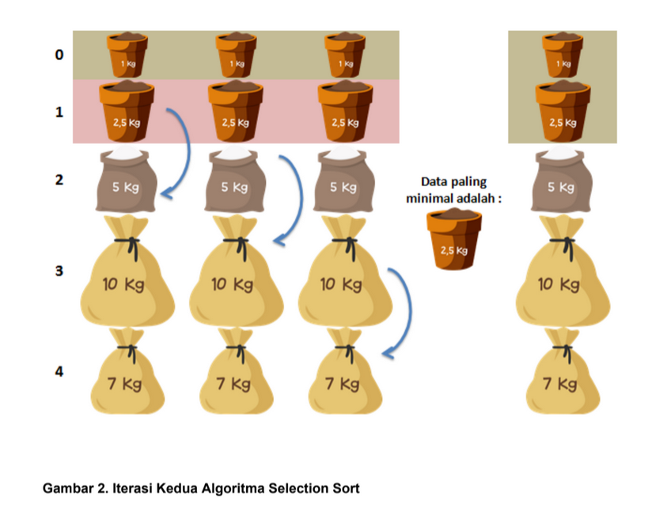

Iterasi Ketiga. Iterasi ketiga bertujuan untuk menempatkan data minimal yang ketiga pada posisi yang tepat, yaitu indeks ke-2. Untuk mencari data minimal ketiga ini, dilakukan perbandingan, hanya saja data pada indeks ke-0 dan ke-1 tidak perlu dibandingkan lagi, karena data pada indeks ke-0 dan ke-1, sudah berisi data yang tepat. Perbandingan yang dilakukan untuk mencari nilai minimal kedua adalah sebagai berikut:

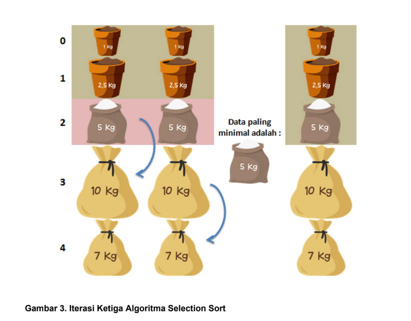

Proses ini dilakukan secara terus menerus sampai proses pengecekan dilakukan pada data terakhir, sehingga akhir dari algoritma selection sort ini, data sudah dalam keadaan terurut, seperti yang terlihat pada Gambar 4.

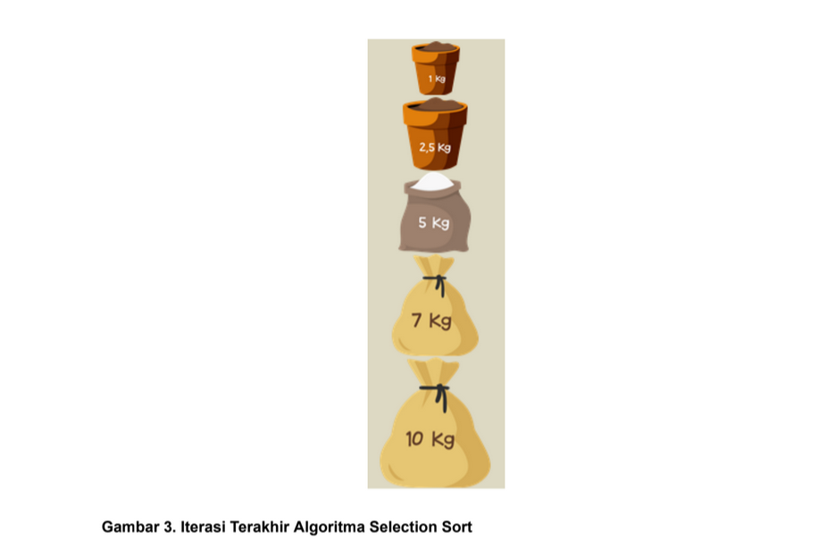

# **CODE**

```python
def selectionSort(listData):
    print('Algoritma Selection Sort konvensional')
    print('Data Awal=',listData)
    for outIter in range(len(listData)-1):
        minIndex=outIter
        for i in range(outIter+1,len(listData)):
            if listData[i]<listData[minIndex]:
                minIndex=i

        temp=listData[outIter]
        listData[outIter]=listData[minIndex]
        listData[minIndex]=temp
        print('Iterasi ke-',outIter+1,':',listData)
    print('Data Urut=',listData)
```

```python
a=[10,2,5,8,1,20,7,12,4]
selectionSort(a)
```

```
Algoritma Selection Sort konvensional
Data Awal= [10, 2, 5, 8, 1, 20, 7, 12, 4]
Iterasi ke- 1 : [1, 2, 5, 8, 10, 20, 7, 12, 4]
Iterasi ke- 2 : [1, 2, 5, 8, 10, 20, 7, 12, 4]
Iterasi ke- 3 : [1, 2, 4, 8, 10, 20, 7, 12, 5]
Iterasi ke- 4 : [1, 2, 4, 5, 10, 20, 7, 12, 8]
Iterasi ke- 5 : [1, 2, 4, 5, 7, 20, 10, 12, 8]
Iterasi ke- 6 : [1, 2, 4, 5, 7, 8, 10, 12, 20]
Iterasi ke- 7 : [1, 2, 4, 5, 7, 8, 10, 12, 20]
Iterasi ke- 8 : [1, 2, 4, 5, 7, 8, 10, 12, 20]
Data Urut= [1, 2, 4, 5, 7, 8, 10, 12, 20]
```